# 3.0 Principal Component Analysis

## Goals

- Dimension reduction technique
- Trying to narrow our dataset to fewer variables

## Eigenvalues and Eigenvectors

These are used to describe the shape of multivariate data. Formal definition: - If A is an n*n matrix, the eigenvalue of A is the scalar (λ) provided there is a nonzero vector $\bar{x}$ that allows the following to be true: - $A\bar{x} = λ\bar{x}$ - λ is the Eigenvalue - A scalar that gives us the magnitude of the Eigenvector - $\bar{x}$ is the Eigenvector of A corresponding to λ - Any nonzero multiple of this matrix is also an Eigenvector of A

[Eigenvalues and Eigenvectors demonstration](https://www.youtube.com/watch?v=5UjQVJu89_Q&feature=emb_title) from Solid Mechanics Classroom:

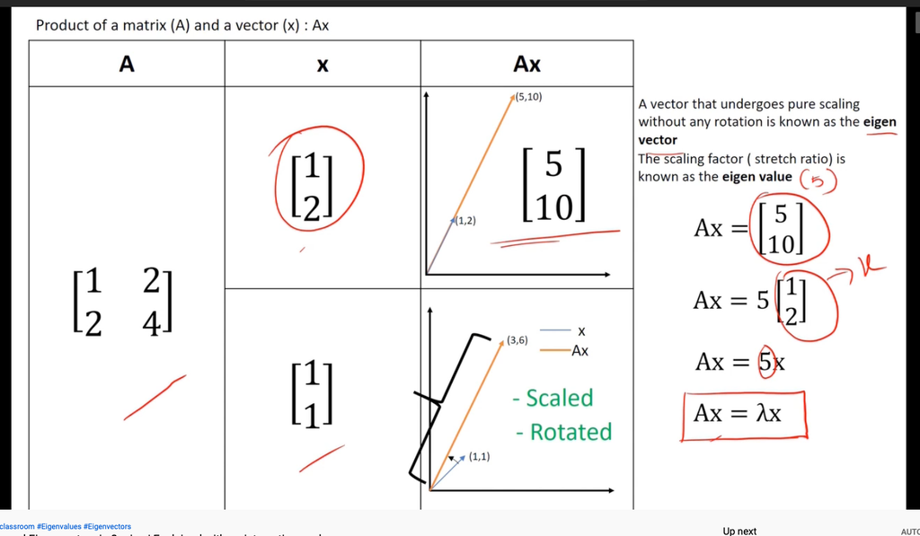

### Eigenvalues

- For an n x n matrix A, there are n eigenvalues $λ_1, λ_2...,λ_ν$ #### Eigenvalue Math $|A - λ_iI = 0$
- i is 1…n
- A: Determinant of Matrix A
- I = identity matrix
- Solving gives us eigenvalue $λ_ι$ for i = 1…n #### Eigenvalues in R
- Use the `eigen(A)` function
  - Pass in the matrix, in this case ‘A’
  - Returns the values and vectors as a list, respectively
  - We can pull the value directly from that list with `eigen(A)$value`
- In this example we store the eigenvalues in ‘lambda’

```r
A <- matrix (c(2, -3, -3, 1), nrow = 2)
lambda <- eigen(A)$value

# For 2 x 2 matrix, we have 2 eigenvalues:
lambda
```

```
[1]  4.5 -1.5
```

#### Math and R

- Remember our equation:

  $|A - λ_iI = 0$
- If we plug in our eigenvalue and identity matrix, we should get zero
- Use `diag()` to find the identity matrix

```r
# identity matrix
I <- diag(2)
```

```r
# first eigenvalue
i=1

# Eigenequation, using eigenvalues (lambda) and identity matrix (I)
round(det(A-lambda[i]*I), 10) # round to 10 decimal places
```

```
[1] 0
```

```r
# The second eigenvalue
 i=2
round(det(A-lambda[i]*I), 10) # round to 10 decimal places
```

```
[1] 0
```

### Eigenvector

#### Math

- If we know scalar λ is an eigenvalue of A, then there is a nonzero vector x with this relationship: $Ax_i = λ_ix_i$ or $Ax = λx$
- Fancy algebra gives us: $(A - λ_iI)x_i = 0$

#### Eigenvector in R

- Similar to before, we can use the `eigen()` function
  - This time we pull `eigen()$vector` out and store it in x

```r
A <- matrix (c(3, 1, 0, 2), nrow = 2)
lambda <- eigen(A)$value
  x <- eigen(A)$vector
# for 2 x 2 matrix, we have 2 eigenvectors
x
```

```
     [,1] [,2]
[1,] 0.71    0
[2,] 0.71    1
```

Check the first eigenvalue and vector

```r
I <- diag(2)

# first eigenvalue
i = 1

# solve and round to 10 decimal places
round((A-lambda[i]*I) %*% x[,i], 10)
```

[output not shown]

### Eigenvector/value of a Covariance Matrix

- The eigenvector of a covariance matrix shows the directions where the data varies the most
  - The first eigenvector is the overall most
  - The second eigenvector is the direction of greatest variance orthogonal (perpendicular) to the first vector
  - Third…and so on
- The eigenvalue is the magnitude of that variability #### Find in R The sum of the diagonals of the covariance matrix is the total variance of the data, which is equal to the sum of eigenvalues
1. Define a covariance matrix S
2. Compare sum of the diagonals of S with the sum of the eigenvalues

```r
S <- matrix(c(9, -2, -2, 1), nrow = 2, byrow=TRUE)
S
```

```
     [,1] [,2]
[1,]    9   -2
[2,]   -2    1
```

```r
lambda <- eigen(S)$value

# sum the diagonals
trace = sum(diag(S))
trace
```

```
[1] 10
```

```r
sum(lambda)
```

```
[1] 10
```

### Confidence Ellipse

- `ellipse()` from the ellipse package returns the outline of a confidence region for bivariate data
- Ellipse axes: eigenvector
- Ellipse lengths: eigenvalues

```r
install.packages("ellipse")
```

Load libraries:

```r
library(ellipse)
library(MVA)
```

Sample data of soft drink ratings by students - Save the column means and covariance for plotting

```r
coke<-c(6,9, 8, 8, 6,7,5,0,0,5,8,10,3,9,5,0,6,8,9,10,8, 8, 5, 8)
pepsi<-c(10,5, 9,10,10,0,0,0,0,5,7,6,2,6,2,0,2,3,8, 8,7 , 9, 5, 10)
drpepper<-c(8,6,10,0,7,0,5,0,1,10,3, 6,5,8,7,0,8,6,7,0, 6, 2, 6, 7)
cokpep <- cbind(coke,pepsi)
mean.c <- colMeans(cokpep)
Cov <- cov(cokpep)
```

Plot with jitters to vary the data slightly

```r
plot(jitter(coke), jitter(pepsi), ylim =c(-5,15), xlim=c(-5,15))
points(ellipse(Cov, centre = mean.c), type="l")
```

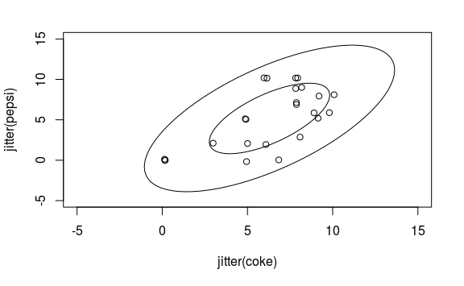

```r
points(ellipse(Cov, centre = mean.c, level=.50), type="l")
```

#### Confidence Interval Axes

1. Define critical values for axes, create the plot as before
2. Define the axes using the first 2 eigenvectors

```r
# define critical values
crit.95 = sqrt(qchisq(.95, 2))
crit.50 = sqrt(qchisq(.5, 2))

# define eigenvector/value
lambda = eigen(Cov)$values
eigvec = eigen(Cov)$vectors

# create plot
plot(jitter(coke), jitter(pepsi), ylim =c(-5,15), xlim=c(-5,15))
points(ellipse(Cov, centre = mean.c), type="l")
```

```r
points(ellipse(Cov, centre = mean.c, level=.50), type="l")

# define axes
axis1.end = mean.c + sqrt(lambda[1])*crit.95*eigvec[,1]
points(rbind(mean.c, axis1.end), type="l")
```

```r
points(rbind(mean.c, axis1.end), pch = "x")

axis2.end = mean.c + sqrt(lambda[2])*crit.95*eigvec[,2]
points(rbind(mean.c, axis2.end), type="l")
```

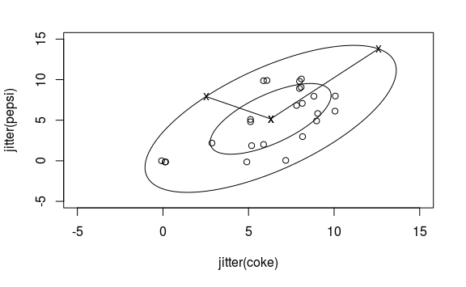

```r
points(rbind(mean.c, axis2.end), pch = "x")
```

## Principal Component Analysis

- PCA is a multivariate technique with the aim of reducing the number of dimensions in a multivariate data set while capture as much of the original variation as possible ### Principal Components
- The original variables are transformed to *principal components* which are linear combinations of the original variables
- PCs are uncorrelated and ordered, with the first few accounting for most of the variation in the original variables
  - Trying to describe variation of correlated variables with a new set of uncorrelated variables
- First principal component
  - The linear combination of original variables with the greatest sample variance among all the possible linear combinations
  - The second principal component is the max of remaining variance being uncorrelated with the first PC, subsequent PCs are defined similarly
    - They are uncorrelated by being orthogonal to the previous PCs ### PCA in R
- Sample data of exam scores in different subjects
  - sshist = social science and history
  - Rest are self explanatory
- Link is broken :( leaving code for reference

```r
test <- read.csv("http://tiny.cc/isqs6350_test", header = T)
head(test)
cov(test)
```

- Use `princomp()`
  - We pass in cor = T to find the PC of standardized data
- Print the results with `summary()` with loading = T

```r
test.pca <- princomp(test, cor = T)
summary(test.pca, loading = T)
```

### Principal Component Scores

- The PC scores are new variables that are linear combinations of the originals based on the eigenvector coefficients
- Eigenvectors are multiplied by scaled variables
- `test.pca$score`

Look at the first six students only:

```r
head(pc1 <- test.pca$score[,1])
```

### Principal Component Analysis of Olympic Heptathlon

Analysis of the 1988 Women’s Heptathlon Olympics

1. Load the data:

```r
data("heptathlon",package="HSAUR2")
head(heptathlon)
```

|  | hurdles | highjump | shot | run200m | longjump | javelin | run800m | score |
| --- | --- | --- | --- | --- | --- | --- | --- | --- |
| Joyner-Kersee (USA) | 13 | 1.9 | 16 | 23 | 7.3 | 46 | 129 | 7291 |
| John (GDR) | 13 | 1.8 | 16 | 24 | 6.7 | 43 | 126 | 6897 |
| Behmer (GDR) | 13 | 1.8 | 14 | 23 | 6.7 | 45 | 124 | 6858 |
| Sablovskaite (URS) | 14 | 1.8 | 15 | 24 | 6.2 | 43 | 132 | 6540 |
| Choubenkova (URS) | 14 | 1.7 | 15 | 24 | 6.3 | 47 | 128 | 6540 |
| Schulz (GDR) | 14 | 1.8 | 14 | 25 | 6.3 | 43 | 126 | 6411 |

2. Clean the data
- We’re going to reverse the values of the hurdles, run200m, and run800m
  - In these events, the winner should have lower values so we’re reversing the direction

```r
heptathlon$hurdles <- max(heptathlon$hurdles)-heptathlon$hurdles
heptathlon$run200m <- max(heptathlon$run200m)-heptathlon$run200m
heptathlon$run800m <- max(heptathlon$run800m)-heptathlon$run800m
```

3. Make a scatterplot matrix to see potential outliers
- Exclude the score variable

```r
mydata <- heptathlon
mydata$score <- NULL
plot(mydata)
```

[output not shown]

4. We notice an outlier, so let’s plot the names to find it

```r
plot(hurdles ~ highjump, data = mydata,
     cex.lab = 0.7,
     xlab = "Highjump",
     ylab = "Hardles")

# adds text to plot
text(hurdles ~ highjump, data = mydata, labels=(row.names(mydata)))
```

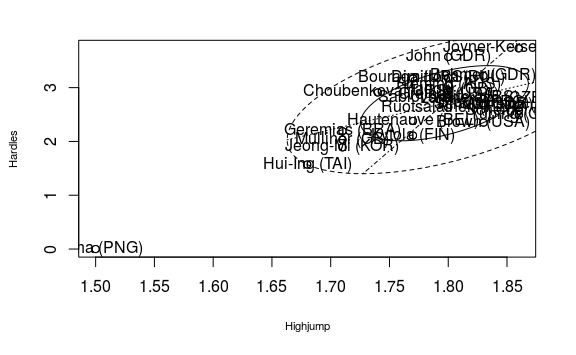

```r
x <- mydata[, c("highjump", "hurdles")]
library(MVA)
bvbox(x, add = T)
```

5. Remove the outlier (PNG)

```r
outlier <- match(lab <- c("Launa (PNG)"), rownames(mydata))
mydata.cln <- mydata [-outlier, ]
```

#### Olympics Principal Component Analysis

- This is a good candidate for PCA since variables are not consistent
  - E.g. we have time and distance
- Summary of data
  - Looking at Cumulative Proportion, we see the first two components account for 75% of variance

```r
heptathlon_pca <- princomp(mydata.cln, cor = T)
summary(heptathlon_pca, loading = T)
```

```
Importance of components:
                       Comp.1 Comp.2 Comp.3 Comp.4 Comp.5 Comp.6 Comp.7
Standard deviation       2.08   0.95   0.91  0.683  0.546  0.337 0.2620
Proportion of Variance   0.62   0.13   0.12  0.067  0.043  0.016 0.0098
Cumulative Proportion    0.62   0.75   0.86  0.931  0.974  0.990 1.0000

Loadings:
         Comp.1 Comp.2 Comp.3 Comp.4 Comp.5 Comp.6 Comp.7
hurdles   0.450         0.174         0.199  0.847
highjump  0.315 -0.651  0.209 -0.557               -0.332
shot      0.402         0.153  0.548 -0.672        -0.229
run200m   0.427  0.185 -0.130  0.231  0.618 -0.333 -0.470
longjump  0.451         0.270         0.122 -0.383  0.749
javelin   0.242 -0.326 -0.881                       0.211
run800m   0.303  0.657 -0.193 -0.574 -0.319
```

Find the linear combination coefficients (also called: loadings, eigenvectors) - Positive and negative signs are based on arbitrary signs of coefficients - Only the magnitude is important

```r
heptathlon_pca$loadings[,1]
```

```
 hurdles highjump     shot  run200m longjump  javelin  run800m
    0.45     0.31     0.40     0.43     0.45     0.24     0.30
```

Finally, we can compare the first principal component to the actual scores (minus the outlier) and see that we have a tight correlation:

```r
cor(heptathlon$score[-outlier], heptathlon_pca$scores[,1])
```

```
[1] 0.99
```

## Biplots

- These are scatterplots showing both the observations and variables of the of an MVA matrix on the same plot
  - Helps to visually interpret the PC axes
- The distance between the observation points reflects the Mahalanobis distance between the units
- The length of the vectors from the origin to a variable coordinate is the variance of that variable
  - The correlation of two variables is represented by the angle between those corresponding vectors for the two variables
    - Smaller angle = greater correlation
- Reading the biplot
  - Points = observations
  - Arrows = variables
  - Only uses the first 2 PCs
  - The angle between arrows is the correlation
    - Smaller angle = similar directions = more correlation
  - Project a data point onto the direction of an arrow gives the measurement of the variable for that data value
  - Short arrows = those variables are not well represented in the first two PCs

We will use the same Heptathlon PCA from above, excluding the outlier:

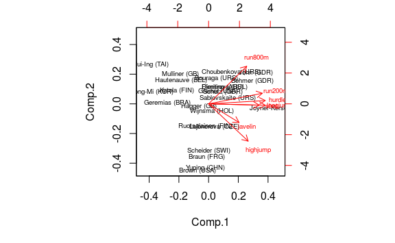

```r
biplot(heptathlon_pca, col=c("black", "red"), cex = 0.6)
```

Check our interpretation by looking at the z-scores, which represent scaled data - For example, we see that Joyner-Kersee scores high in all categories

```r
options(digits = 2)
scale(mydata.cln)
```

```
                    hurdles highjump    shot run200m longjump javelin
Joyner-Kersee (USA)   2.026     1.27  1.7544   2.163     2.65    1.26
John (GDR)            1.715     0.12  2.0417   0.999     1.26    0.37
Behmer (GDR)          1.035     0.69  0.6857   1.587     1.18    0.94
Sablovskaite (URS)    0.238     0.12  1.3737   0.711     0.11    0.43
Choubenkova (URS)     0.432    -1.03  1.0598   0.701     0.29    1.78
Schulz (GDR)         -0.034     0.69  0.2182  -0.068     0.31    0.44
Fleming (AUS)         0.685     0.12 -0.1959   1.063     0.41   -0.29
Greiner (USA)         0.355     0.12  0.6390   0.113     0.66   -0.95
Lajbnerova (CZE)      0.199     0.69  0.7392  -0.292    -0.24    0.27
Bouraga (URS)         0.938    -0.45 -0.3696   1.063     0.19   -0.64
Wijnsma (HOL)        -0.034     1.27 -0.1091  -0.474     0.34   -0.99
Dimitrova (BUL)       0.957     0.12 -0.1959   1.063     0.41   -0.29
Scheider (SWI)       -0.228     1.27 -1.0642  -0.303    -0.39    1.79
Braun (FRG)           0.044     0.69 -0.0089  -0.207    -0.21    0.95
Ruotsalainen (FIN)   -0.112     0.12 -0.5700  -0.025    -0.31    1.20
Yuping (CHN)         -0.384     1.27  0.6924  -0.442     0.48   -0.77
Hagger (GB)           0.510     0.12 -0.2828  -0.943     0.34   -1.59
Brown (USA)          -0.656     0.69 -0.3228  -0.260    -0.19    0.88
Mulliner (GB)        -1.278    -1.60 -0.3295  -0.356    -0.26   -1.01
Hautenauve (BEL)     -0.598    -0.45 -0.9106  -1.093    -0.54   -1.61
Kytola (FIN)         -1.122    -0.45 -1.0108  -1.178    -1.13   -0.52
Geremias (BRA)       -0.967    -1.60 -0.1492  -0.975    -1.76   -0.47
Hui-Ing (TAI)        -2.172    -2.17 -2.1196  -0.687    -1.83   -0.62
Jeong-Mi (KOR)       -1.550    -1.60 -1.5652  -2.160    -1.76   -0.58
                    run800m
Joyner-Kersee (USA)  1.0417
John (GDR)           1.4305
Behmer (GDR)         1.7428
Sablovskaite (URS)   0.4349
Choubenkova (URS)    1.1409
Schulz (GDR)         1.4841
Fleming (AUS)        0.3861
Greiner (USA)        0.2055
Lajbnerova (CZE)    -0.1849
Bouraga (URS)        0.0282
Wijnsma (HOL)        0.5569
Dimitrova (BUL)      0.3861
Scheider (SWI)      -0.0027
Braun (FRG)         -1.2862
Ruotsalainen (FIN)  -0.3492
Yuping (CHN)        -1.9125
Hagger (GB)         -0.5802
Brown (USA)         -1.8735
Mulliner (GB)       -0.5054
Hautenauve (BEL)     0.1648
Kytola (FIN)         0.2543
Geremias (BRA)      -1.4814
Hui-Ing (TAI)       -0.3882
Jeong-Mi (KOR)      -0.6925
attr(,"scaled:center")
 hurdles highjump     shot  run200m longjump  javelin  run800m
     2.7      1.8     13.2      2.0      6.2     41.3     28.5
attr(,"scaled:scale")
 hurdles highjump     shot  run200m longjump  javelin  run800m
   0.515    0.052    1.497    0.937    0.402    3.469    6.147
```

### Angle between Arrows

- To better intuit we can look at the correlation between the PC2 score and the original variables
  - Notice the positive sign variables also have positive angles to the horizontal line in the middle

```r
cor(heptathlon_pca$scores[,2], mydata.cln)
```

```
     hurdles highjump   shot run200m longjump javelin run800m
[1,]   0.055    -0.62 -0.021    0.18   -0.024   -0.31    0.62
```

## Canonical Correlation Analysis (CCA)

- Used for assessing relationships between two sets of variables rather than within a set of variables
  - Allows us to see what may be common among two sets of data
- The goal is finding linear functions of variables in one set that maximally correlate with linear functions in the other
- A generalization of multiple regression where several variables Y are simultaneously related to multiple variables X ### CCA Math
- More than one pair of canonical variables can be calculated
- For q variables $X_1, X_2...,X_q$ and p variables $Y_1, Y_2...,Y_p$ CCA finds up to the minimum of q and p variables
- $min(q,p)$

Given data sets: $U_1 = a_{11}X_1+a_{12}X_2+...+a_{1q}X_q$ $U_2 = a_{21}X_2+a_{22}X_2+...+a_{2q}X_q$ … $U_3 = a_{q1}X_1+a_{q2}X_2+...+a_{qq}X_q$ and $V_1 = b_{11}Y_1+b_{12}Y_2+...+b_{1p}Y_p$ $V_2 = b_{21}Y_1+b_{22}Y_2+...+b_{2p}Y_p$ … $V_p = b_{p1}Y_1 + b_{p2}Y_2 +...+b_{pp}Y_p$

Choose the pairs of canonical variables: $(U_1,V_1),(U_2, V_2),...,(U_{min(p,q)},V_{min(p,q)})$ - The correlation between $U_1$ and $V_1$ is the maximum - The correlation between $U_2$ and $V_2$ is the maximum uncorrelated to $U_1$ and $V_1$ - And so on ### CCC in R - Use the `cc()` function from the CCA package - Sample data: student evaluations - CSV link broken :/

```r
data <- read.csv("http://tiny.cc/isqs6350_evals")
```

```
cannot open URL 'https://tiny.cc/isqs6350_evals': HTTP status was '404 Not Found'Error in file(file, "rt") :
  cannot open the connection to 'http://tiny.cc/isqs6350_evals'
```

1. Install the CCA package

```r
install.packages("CCA")
require(CCA)
```

2. Store the ratings for instructor’s performance and course evaluation

```r
X <- evals[, 1:10] # instructor's performance
Y <- evals[, 11:16] # course evaluation
cca <- cc(X,Y) # CCA function
```

3. Print the correlations from the analysis

```r
round(cca$cor,3)
```

[output not shown]